# **How Does Age Impact Running**

## **Introduction**

Running success is influenced by a wide variety of factors (Venturini and Giallauria). These include but are not limited to:

- Training
- Genetics
- Environmental Conditions

A factor that has garnered considerable interest is age. It is believed to affect a runner's speed and endurance (Strain Daniel), but is this true, and if it is to what extent? While studies have previously explored the relationship betIen age and performance in other sports (Rey et al.), running offers unique challenges due to its reliance on both aerobic and anaerobic fitness, which changes over the course of a person's life. In this paper, I aim to find whether age plays a significant role in determining running times. I will focus on olympic distances such as the 1,500m, the 10,000m, and the 100m. I will be analyzing a diverse range of runners within the top 1000 fastest times for their respective event with the goal of providing insight into how age correlates with running performance and whether it is a factor that should be considered when evaluating race results, and, if so, to what extent.

## **Methodology**

I will be analyzing a csv file consisting of data scraped off of https://www.alltime-athletics.com/index.html (Top Running Times). It consists of the top 1000 running times across olympic distances for both men and women. It contains the following data for each entry:

- Rank
- Time
- Name
- Country
- Date of Birth
- Place
- City
- Date
- Gender
- Event

I will first import the necessary libraries. I will use Numpy to do large efficient calculation on large sums of data. Pandas will be used to store, display, and find correlations within the data. Mathplotlib will help visualize the findings. Additionally, Seaborn will compliment Mathplotlib's graphing abilities by adding more graphing options to my toolkit.

```python
import numpy as np
import pandas as pd
import matplotlib.pyplot as plt
import seaborn as sns
```

Although pandas is slightly more inefficient compared to Numpy, I will use pandas to store the data and read the file as I am working with a csv file. Numpy's `genfromtext()` does support reading csv files, however, the dataset features commas in values such as the distance for each event which makes it complicated for Numpy's delimeter to separate the values into commas, thus why Pandas is preferred as the `thousands=","` argument ensures the commas in the numerical values aren't read as delimeters.

```python
# Found the thousands argument here ---> https://pandas.pydata.org/docs/reference/api/pandas.read_csv.html
# Reads the data
data = pd.read_csv("runData.csv", thousands=",")
# Retrieves general information about how the data is stored and prints
print((data.dtypes))
```

```
Rank               int64
Time              object
Name              object
Country           object
Date of Birth     object
Place            float64
City              object
Date              object
Gender            object
Event             object
dtype: object
```

Using `.dtypes` as shows in the previous output, I am able to observe how pandas is storing the data. Only Rank and Place are being saved properly as 64bit integers or floats, therefore I will have to clean the rest of the data, or at least the data used for this paper. Thankfully the cleaning process isn't too hard as it mostly consists of simple conversions into standard data types such as strings or integers. I start by converting the event names into a value of type string as this will allow me to use data within a specific distance group or event. I do this by using the method `.astype(str)` which interprets the event data as a string.

```python
# Clean event names
data["Event"] = data["Event"].astype(str)
```

Apart from the event data I will also need to know the athlete's age and running time. I can calculate the age of the athlete by subtracting their birthdate from the date of the race, but to perform this operation I will first need to clean both values. Pandas makes this easy with the `.to_datetime` method which allows me to specify the format in which the data is stored so that pandas can interpret it properly as a `datetime64` object. Now using the `dt` or datetime accessor I can access the method .days which returns a integer value storing the number of days within my `datetime64` object. Finally, since I am working with integers now, I can simply divide the amount of days by 365 to obtain the final age of the athlete.

```python
# Calculate how many years have passed from birth to day of race

# Clean birth date
birthDate = pd.to_datetime(data["Date of Birth"], format= "%Y-%m-%d")
# Clean Race date
raceDate = pd.to_datetime(data["Date"], format= "%Y-%m-%d")
# Get the time that has passed between the athlete's birthdate and the date of their race
data["yearsPassed"] = raceDate - birthDate
# Convert to int64 and years
data["ageAtRace"] = data["yearsPassed"].dt.days / 365
```

I use a similar method to clean the running times. Using `.to_timedelta` which returns the times as `datetime64` objects again. Now, I can convert into floats using the datetime accessor again and converting to seconds using `.total_seconds()`

```python
# --------- Time Running --------
# Convert to time
# Got this from the API https://pandas.pydata.org/pandas-docs/stable/reference/api/pandas.to_timedelta.html
data["TimeRunning"] = pd.to_timedelta(data["Time"])
# To get the time in seconds as floats
# Got this from the API too https://pandas.pydata.org/pandas-docs/stable/reference/api/pandas.Series.dt.total_seconds.html. I convert to seconds and store as a float value
data["TimeRunningSeconds"] = data["TimeRunning"].dt.total_seconds()
```

Now, I am able to find the correlation between the running times and the age of the athlete using `corr()`. I start by creating a new dataframe composed of solely integers so that we can find the correlation in values within it.

```python
#Get Correlation
cleanCorrelationData = data[['TimeRunningSeconds', 'ageAtRace']]
print(cleanCorrelationData.corr())
```

```
                    TimeRunningSeconds  ageAtRace
TimeRunningSeconds            1.000000   0.204124
ageAtRace                     0.204124   1.000000
```

The program returns a correlation coefficient of 0.204 which indicates a weak positive correlation. This indicates that the times do increase slightly as we become older and that age does indeed play a factor within the running times.

I decided to graph this in order to visualize the correlation through the use of a trendline and a line representing the mean. In theory I should see the trendline go above the mean line as the age of the athlete's increase. To do this I have to do some setup first. For one, if I simply graph all of the values I will get isolated clusters of data due to time differences between different events and sex of the athletes, thus I will narrow down the graph to the men's 1500 event first.

```python
# Specify males within the 1500 meter
mileEventDataMen = data[(data["Event"] == "1500 m") & (data["Gender"] == "Men")]
```

Now I am able to find statistical measures (such as `mean()`) within the Men's 1500 meter event:

```python
#Get mean time (Average)
meanTime = mileEventDataMen["TimeRunningSeconds"].mean()
```

I also can now plot this using mathplotlib. I will be ploting the times over the age. In order to notice the general trend for times (wether they get faster or slower as one ages) I will plot the mean time as a dashed line and the trend line as a polynomial. This is done so that I can clearly observe whenever the trend polynomial is below or above the mean line as that indicates that our runner's are faster or slower than the average runner.

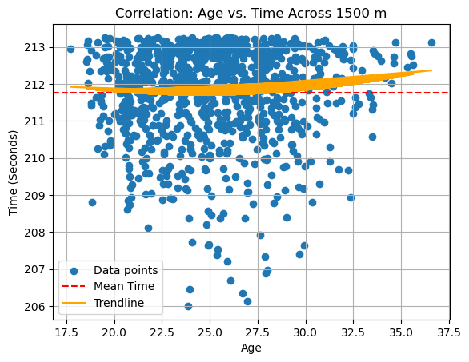

```python
# Scatter plot
plt.scatter(mileEventDataMen["ageAtRace"], mileEventDataMen["TimeRunningSeconds"], label='Data points')

# Plot mean running times
plt.axhline(y=meanTime, color='red', linestyle='--', label="Mean Time")

# Plot trendline
# Learned about polyval from https://numpy.org/doc/stable/reference/generated/numpy.polyval.html
coeffs = np.polyfit(mileEventDataMen["ageAtRace"], mileEventDataMen["TimeRunningSeconds"], 2)
trendline = np.polyval(coeffs, mileEventDataMen["ageAtRace"])
plt.plot(mileEventDataMen["ageAtRace"], trendline, color='orange', label='Trendline')

#Graph Formatting
plt.title('Correlation: Age vs. Time Across 1500 m')
plt.xlabel('Age')
plt.ylabel('Time (Seconds)')
plt.legend()
plt.grid(True)
plt.show()
```

Observed above is a scatter plot of our running times within the men's 1500 meter event. The dotted red line represents the mean and the orange polynomial represents the trend line. By observing our trend line we can see our times decrease in youth (trend line decreasing) as you become faster than the average runner (the trend line dips below the mean line) at roughly 21 years old before our times start increasing again as we age (observed by our tend line increasing) until you are once again slower than the average runner at roughly 29 years old. This analysis is possbible because of the earlier decision to use a polynomial for the trend line which was done because the relationship between age and running times is not linear and instead follows a U shape (which can even be observed in the formation of our data points) as a runner improves in youth, peaks in adulthood, and gets slower as they age.

I will also graph the times across different age groups and more importantly what the most common times are for each age group as this will aid in my understanding of to what extent aging affects running times. I will be doing this with the help of another graphing library called Seaborn, specifically its ability to create box plots for the different age bands. First I will create the different age groupings. I will be defining each of the age groups as variables instead of data frames and adding the `.copy()` behavior to tell pandas that these are new datasets and not to modify the original so that I can avoid any later errors (In particular this one `SettingWithCopyWarning` error/warning).

```python
seventeenTwenty = mileEventDataMen[(mileEventDataMen["ageAtRace"] >= 17) & (mileEventDataMen["ageAtRace"] < 20)].copy()
twentyTwentyThree = mileEventDataMen[(mileEventDataMen["ageAtRace"] >= 20) & (mileEventDataMen["ageAtRace"] < 23)].copy()
twentyThreeTwentySix = mileEventDataMen[(mileEventDataMen["ageAtRace"] >= 23) & (mileEventDataMen["ageAtRace"] < 26)].copy()
twentySixTwentyNine = mileEventDataMen[(mileEventDataMen["ageAtRace"] >= 26) & (mileEventDataMen["ageAtRace"] < 29)].copy()
twentyNineThirtyTwo = mileEventDataMen[(mileEventDataMen["ageAtRace"] >= 29) & (mileEventDataMen["ageAtRace"] < 32)].copy()
thirtyTwoThirtyFive = mileEventDataMen[(mileEventDataMen["ageAtRace"] >= 32) & (mileEventDataMen["ageAtRace"] < 35)].copy()
thirtyFiveForty = mileEventDataMen[(mileEventDataMen["ageAtRace"] >= 35) & (mileEventDataMen["ageAtRace"] < 40)].copy()
```

Next, I will plot the different age groups. To do this I must access the data within the newly variables and reset their value to their age group instead of a specific age.

```python
#Accesses our age group variables and creates a column called ageGroup where the values are set to their respective age groups
seventeenTwenty["ageGroup"] = "17-20"
twentyTwentyThree["ageGroup"] = "20-23"
twentyThreeTwentySix["ageGroup"] = "23–26"
twentySixTwentyNine["ageGroup"] = "26–29"
twentyNineThirtyTwo["ageGroup"] = "29–32"
thirtyTwoThirtyFive["ageGroup"] = "32–35"
thirtyFiveForty["ageGroup"] = "35–40"
```

Now, I will use pandas's `concat()` function to add all of our groups into one single data frame containing the ages now grouped into their respective groups.

```python
# Groups all data into a single dataframe using concat() which I learned how to use from this https://pandas.pydata.org/docs/reference/api/pandas.concat.html
groupedData = pd.concat([
    seventeenTwenty,
    twentyTwentyThree,
    twentyThreeTwentySix,
    twentySixTwentyNine,
    twentyNineThirtyTwo,
    thirtyTwoThirtyFive,
    thirtyFiveForty
])
```

Finally I can plot the data using Seaborn and Mathplotlib. I will specifically be using `boxplot()` which allows me to clearly see the distribution for each age group. I will use `plt.figure` to set the size of our chart and both `plt.tight_layout()` and `plt.xticks()` to help make our graph clearly readable. Most importantly I will use Seaborn's `boxplot()` to represent the distributions of times within their age groups.

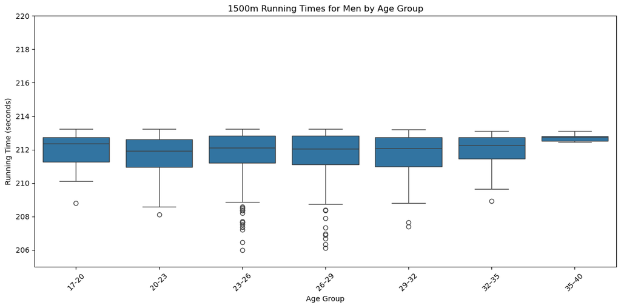

```python
# Create our boxplot
plt.figure(figsize=(12, 6)) # Size of boxplot
sns.boxplot(x="ageGroup", y="TimeRunningSeconds", data=groupedData)

#Formatting
plt.title("1500m Running Times for Men by Age Group")
plt.xlabel("Age Group")
plt.ylabel("Running Time (seconds)")
plt.xticks(rotation=45)
plt.ylim(205, 220)  # adjust according to your data range
plt.tight_layout()
plt.show()
```

Outputted above is the box plot of our times for each age group. Any dots on the graph are outliers within their age groups and the horizontal grey line within each box represents the median for that age band. The lower whisker represents the approximate minimum value and the line in the top represents the approximate max value. The boxes themselves represent the middle 50% of our data which is called the interquartile range (IQR)

#### **Analyzing The Rest of The Data Set: Creating a function.**

Now I need to find a way to perform this analysis on multiple events and for both sexes. There are two options present: Repeat the exact same code and create new variables for each event, although very inneficient it would require minimal work on my part and would mostly be monotonous work in the form of copy pasting; alternatively, I can instead create a function that combines all of the previously done analysis and performs it for a given data set and sex. I choose to go for the latter as it will allow me to easily analyze a wide range of my data. The function works by performing all of the previously written code, except that I define the data I want to run the code on from the start through the function's arguments, additionally I assigned defined the `["ageAtRace"]` collumn and `["TimeRunningSeconds"]` as x and y variables respectively which cut down on the percieved complexity of the operations signficantly. Additionally since I will be outputting a lot of graphs I had to change my approach to plotting. Most of the code remains the same but I now use the figure system (matplotlib.figure — Matplotlib 3.10.3 Documentation) to create subplots. What this means for the code is that I now initially setup my subplots `fig, axes = plt.subplots(1, 2, figsize=(16, 6))`, and I replace `plt` with the corresponding axes of our specific graph which would be `axes[0]` for the scatter plot and `axes[1]` for the box plot.

```python
# Function to analyze any given event. Takes in eventName of type string in the format "distance m", eventSex of type string in the format "Sex",
# I used this https://stackoverflow.com/questions/43233535/explicitly-define-datatype-in-python-function stack overflow discussion to determine how to define arguments as a specific type.
def analyzeEvent(eventName: str, eventSex: str):
    # Print the event under analyzis
    print(f"{eventSex}'s {eventName}")
    # Create a data set within the specific event we want to analyze
    specificEvent = data[(data["Event"] == eventName) & (data["Gender"] == eventSex)]

    ## ------------------------------------------- SETUP SUBPLOTS --------------------------------------------------- //
    # Set up subplots: 1 row and 2 columns, you can adjust their size here too
    fig, axes = plt.subplots(1, 2, figsize=(16, 6))

    ## -------------------------------------------- GENERIC PLOT --------------------------------------------------- //
    # Useful for showing to what degree or whether there even is an impact on a runner's performance as they age

    # Assign Values for our x and y within our graph
    xGenericGraph = specificEvent["ageAtRace"]
    yGenericGraph = specificEvent["TimeRunningSeconds"]

    # Generate scatter plot
    # Added in axes as they represent out individual box plots so axes[0] is our scatter plot
    axes[0].scatter(xGenericGraph, yGenericGraph)

    #Get mean time (Average Time)
    genericGraphMean =yGenericGraph.mean()

    # Plot mean running times
    axes[0].axhline(y=genericGraphMean, color='red', linestyle='--', label="Mean Time")

    # Plot trendline
    # Learned about polyval from https://numpy.org/doc/stable/reference/generated/numpy.polyval.html
    coeffs = np.polyfit(xGenericGraph, yGenericGraph, 2)
    trendline = np.polyval(coeffs, xGenericGraph)
    axes[0].plot(xGenericGraph, trendline, color='orange', label='Trendline')

    #Graph Formatting
    axes[0].set_title(f'Age vs. Time for {eventSex}\'s {eventName}')
    axes[0].set_xlabel('Age')
    axes[0].set_ylabel('Time (Seconds)')
    axes[0].legend()
    axes[0].grid(True)



    ## -------------------------------------------- BOX PLOT --------------------------------------------------- //
    # Useful for vizualizing our different age groups and how athelethes can expect to perform at each stage of their running career

    # Create variables to store a copy of our data for each of our age bands
    seventeenTwenty = specificEvent[(xGenericGraph >= 17) & (xGenericGraph < 20)].copy()
    twentyTwentyThree = specificEvent[(xGenericGraph >= 20) & (xGenericGraph< 23)].copy()
    twentyThreeTwentySix = specificEvent[(xGenericGraph >= 23) & (xGenericGraph < 26)].copy()
    twentySixTwentyNine = specificEvent[(xGenericGraph >= 26) & (xGenericGraph < 29)].copy()
    twentyNineThirtyTwo = specificEvent[(xGenericGraph >= 29) & (xGenericGraph < 32)].copy()
    thirtyTwoThirtyFive = specificEvent[(xGenericGraph >= 32) & (xGenericGraph< 35)].copy()
    thirtyFiveForty = specificEvent[(xGenericGraph >= 35) & (xGenericGraph< 40)].copy()

    # Replace age values with age groupings
    seventeenTwenty["ageGroup"] = "17-20"
    twentyTwentyThree["ageGroup"] = "20-23"
    twentyThreeTwentySix["ageGroup"] = "23–26"
    twentySixTwentyNine["ageGroup"] = "26–29"
    twentyNineThirtyTwo["ageGroup"] = "29–32"
    thirtyTwoThirtyFive["ageGroup"] = "32–35"
    thirtyFiveForty["ageGroup"] = "35–40"

    # Group into a single dataframe
    groupedData = pd.concat([
    seventeenTwenty,
    twentyTwentyThree,
    twentyThreeTwentySix,
    twentySixTwentyNine,
    twentyNineThirtyTwo,
    thirtyTwoThirtyFive,
    thirtyFiveForty
])
    # Create our boxplot
    plt.figure(figsize=(12, 6)) # Set Size
    # Added in ax= to define this box plot as axes[1]
    sns.boxplot(x="ageGroup", y="TimeRunningSeconds", data=groupedData, ax=axes[1])

    #Formatting
    axes[1].set_title(f'{eventName} Running Times by Age Group ({eventSex})')
    axes[1].set_xlabel("Age Group")
    axes[1].set_ylabel("Running Time (seconds)")
    axes[1].tick_params(axis='x', rotation=45)

    # Show plots
    plt.tight_layout()
    plt.show()
```

Now I can use this function to easily perform a complete analysis. This analysis is done by looking at the scatter plot to identify the general trend and then looking at the box plot's whiskers to determine at what point will a runner be at their physical best (whenever the whisker is the lowest.). I did this for the following events which ive grouped into sprints, middle distance, and long distance according to commonly accepted groupings (“[No.5 Sprints And Middle And Long Distance Runs]Ultimate Performances That Develop on The Track”).

#### **Sprints: 100m, 200m, and 400m**

```
Men's 100 m
```

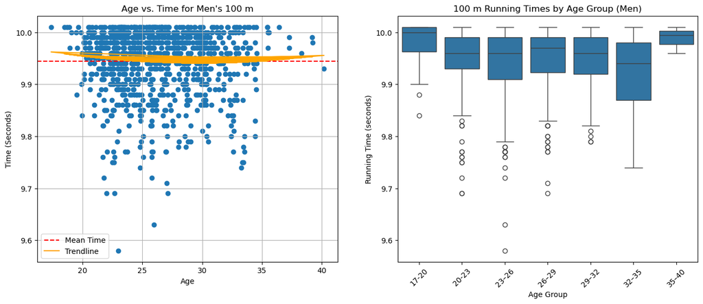

```python
# 100m
analyzeEvent("100 m", "Men")
```

**Men's 100 M:** You will most likely be at your fastest when you are 23-26 years old or later at 32-35 years old. It is worth noting that you will only be at your physical best (when you have the most potential to go fast) at 32-35 years old.

```
Women's 100 m
```

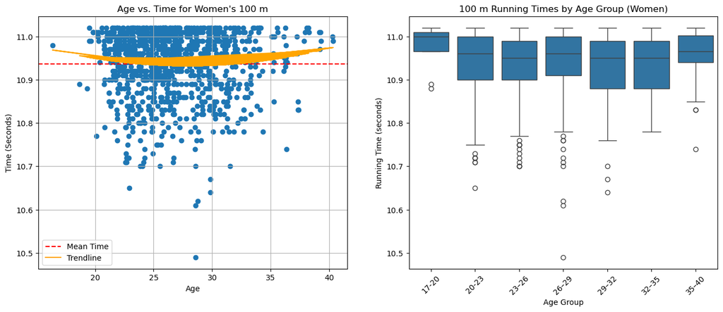

```python
analyzeEvent("100 m", "Women")
```

**Women's 100 M:** You will most likely be at your fastest when you are 23-26 years old and will only start getting slower after 35-40 years old.

```
Men's 200 m
```

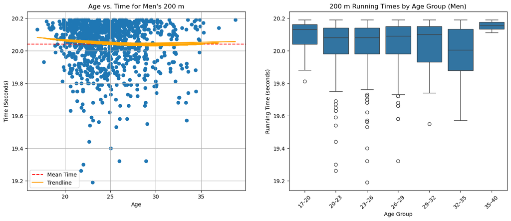

```python
# 200m
analyzeEvent("200 m", "Men")
```

**Men's 200 M:** You will continue getting faster until 32-35 years old when you'll be at your fastest. After 35 years old you will see a drastic decline in times and will become much slower.

```
Women's 200 m
```

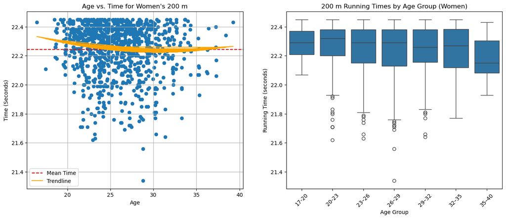

```python
analyzeEvent("200 m", "Women")
```

**Women's 200 M:** You will keep getting faster even until you are 40 years old (There was no data for women older than that), however you will be at your physical best at 26-29 years old and at almost the same physical capacity at 32-35 years old.

```
Men's 400 m
```

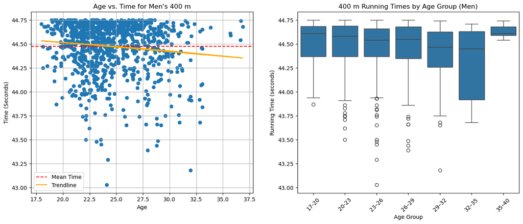

```python
#400m
analyzeEvent("400 m", "Men")
```

**Men's 400 M:** You will continue getting faster until 32-35 years old when you'll be at your fastest. After 35 years old you will see a drastic decline in times and will become much slower. As opposed to most other distances the bulk of the fastest runners are those who are the oldest in the age group of 32-35 years old.

```
Women's 400 m
```

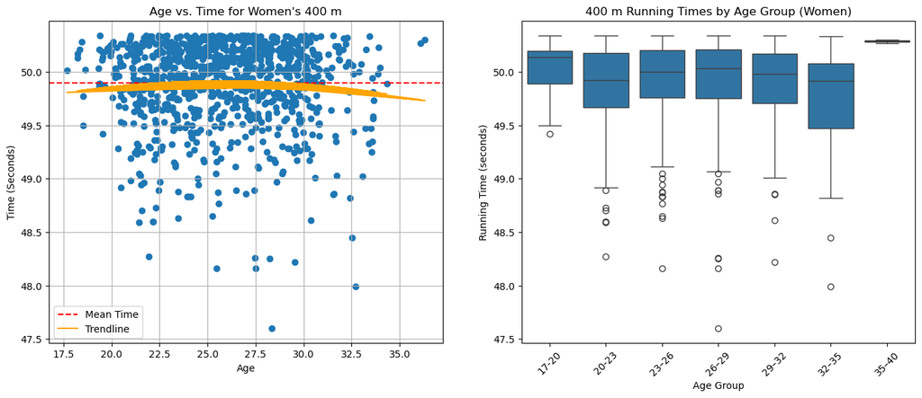

```python
analyzeEvent("400 m", "Women")
```

#### **Middle-Distance: 800m and 1,500m**

```
Men's 800 m
```

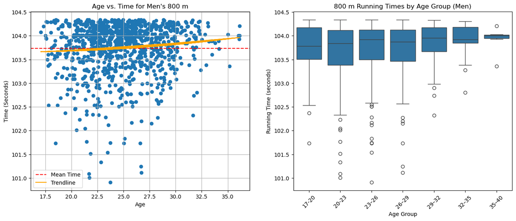

```python
# 800m
analyzeEvent("800 m", "Men")
```

**Men's 800 M:** You will continue getting faster until 20-23 years old when you'll be at your fastest. After you will only keep getting slower with a sharp decline after turning 29-32 years old.

```
Women's 800 m
```

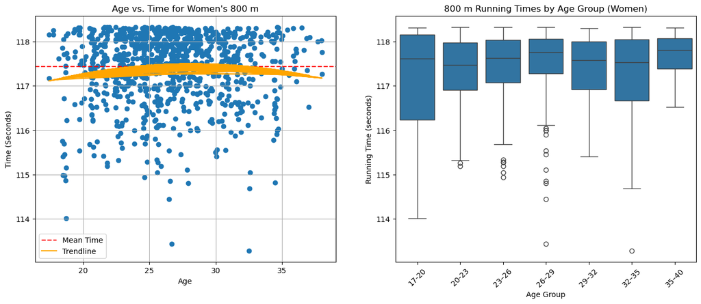

```python
analyzeEvent("800 m", "Women")
```

**Women's 800 M:** You will be at your fastest from 17-20 years old. After you will get slower until you are 29-32 years old when you will keep getting faster again until you are at your second fastest at 32-35 years old, before finally seeing a drastic decline from 35 years old onwards.

```
Men's 1500 m
```

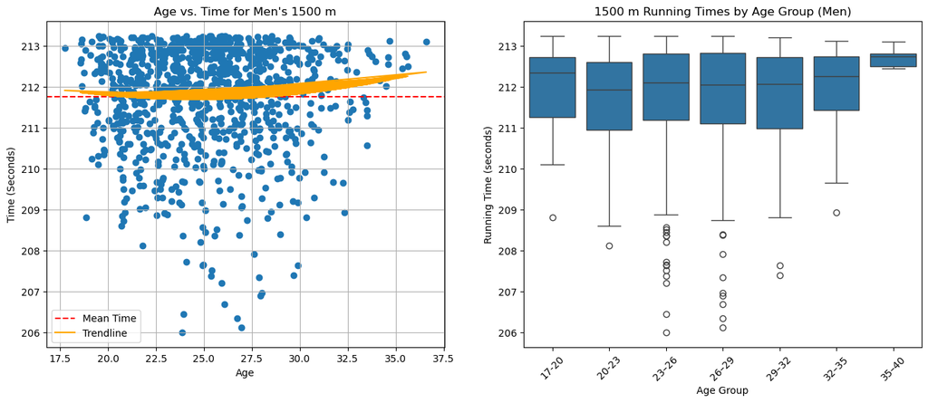

```python
# 1500m
analyzeEvent("1500 m", "Men")
```

```
Women's 1500 m
```

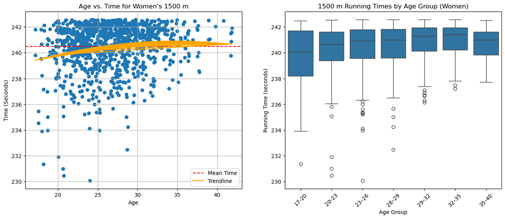

```python
analyzeEvent("1500 m", "Women")
```

**Women's 1500 M:** You will be at your fastest from 17-20 years old. After you will only get slower although it is worth noting that even at 35-40 you will not be much slower than 29-32 years old.

#### **Long-Distance: 5,000m and 10,000**

```
Men's 5000 m
```

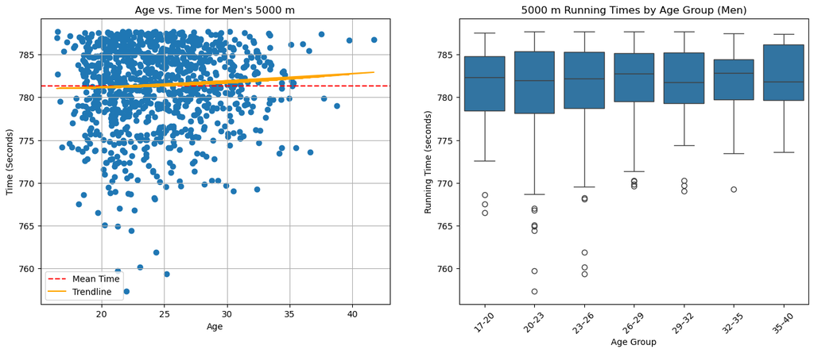

```python
# 5000m
analyzeEvent("5000 m", "Men")
```

**Men's 5000 M:** You will get faster until you are 20-23 years old when you will be at your physical best, afterwards you will get slower until being at your slowest at 29-32 before seeing a slight speed increase from 32-40.

```
Women's 5000 m
```

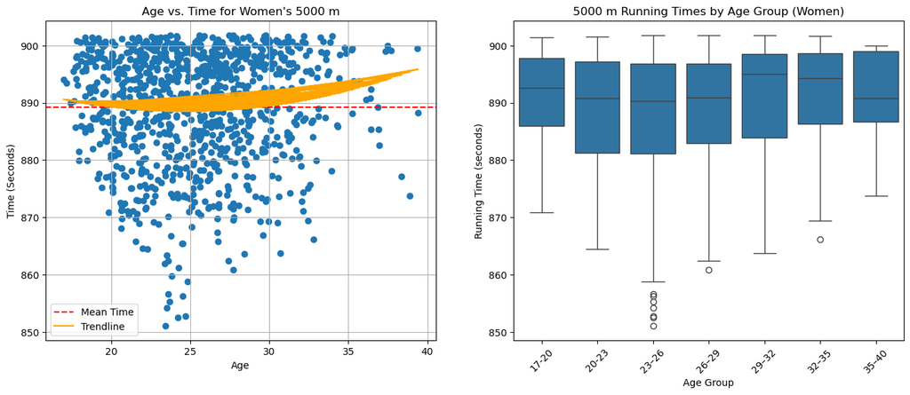

```python
analyzeEvent("5000 m", "Women")
```

**Women's 5000 M:** You will get faster until you are 23-26 years old when you will be at your physical best, afterwards you will continously get slower.

```
Men's 10,000 m
```

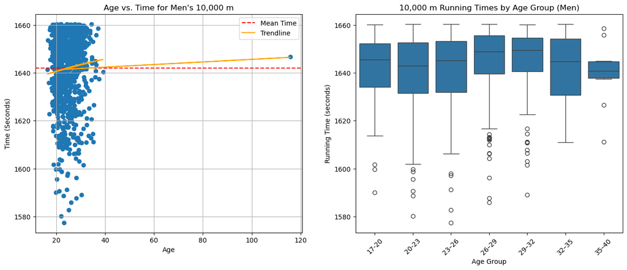

```python
# 10,000m
analyzeEvent("10,000 m", "Men")
```

**Men's 10,000 M:** You will get faster until you are 20-23 years old when you will be at your physical best, afterwards you will get slightly slower as you age until you reach 32-35 years old where you will periodically surge to be slightly faster than when you were 26-29 years old. Afterwards you will significantly get slower at 35-40 years old.

```
Women's 10,000 m
```

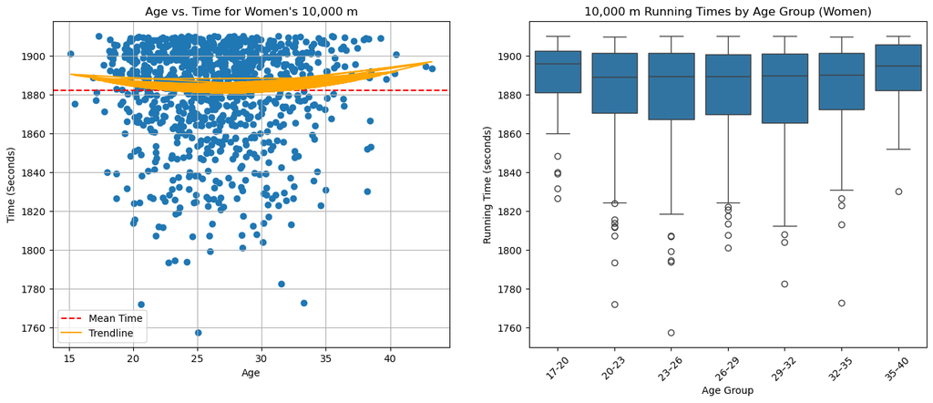

```python
analyzeEvent("10,000 m", "Women")
```

**Women's 10,000 M:** You will get faster until you are 29-32 years old when you will be at your physical best, afterwards you will get slower as you age until being significantly slower at 35-40 years old.

# **Discussion**

### **Interpretations**

These findings suggest that the impact of aging on running performance depends highly on the event and gender. Sprint events tend to allow for later peaks, most likely due to the dependency on strength and power, which decline more slowly than aerobic capacity (Razmus). In direct contrast are middle and long-distance events, which show earlier peaks, probably because of the greater cardiovascular demands that diminish earlier with age (Razmus).

### **Implications**

This analysis will be useful for athletes, coaches, and sports scientists. Understanding when athletes will likely peak in specific events allows coaches or athletes themselves to be able to optimize training cycles, career planning, and load management. It also challenges some age-related stereotypes, especially regarding women’s athletic potential in their 30s. The results highlight that age alone is not enough to determine performance and that elite athletes can still maintain exceptional ability well beyond early adulthood.

### **Limitations and Biases**

Important to note is how the dataset is solely composed of elite runners. This limits how general our findings are and shifts them away from the broader population of amateur or recreational runners, who might experience greater performance declines with age. Moreover, uneven sample sizes across age groups, especially for older female athletes, may have skewed some results. The analysis also didn’t account for other critical factors such as injury history, training load, or even technological advances such as super shoes, which may influence performance independently of age.

### **Recommendations for Future Work**

Future research should include non-elite athletes in order to capture much broader trends in age-related performance decline. By incorporating additional variables such as training background, injuries, and recovery practices, we could provide a more complete picture, too. Tracking the same athletes across time could reveal more nuanced patterns of aging in performance. More advanced modeling techniques, such as machine learning, could be used to predict peak age or detect performance anomalies.

# **Conclusion**

The research found that age has a modest effect on running performance, yet the impact depends heavily on event type and gender. Elite sprinters often peak later than distance runners, and many women sustain high performance well into their mid-30s. These findings provide a data-driven understanding of how age influences athletic ability, and could potentially help athletes and coaches make informed decisions. More broadly, the findings emphasize that age should not be seen as a strict limitation but as one factor among many in determining athletic potential.

# **Bibliography**

Venturini, Elio, and Francesco Giallauria. “Factors Influencing Running Performance During a Marathon: Breaking the 2-h Barrier.” Frontiers in Cardiovascular Medicine, vol. 9, Mar. 2022, https://doi.org/10.3389/fcvm.2022.856875.

Strain Daniel, “Why Do We Move Slower the Older We Get? New Study Delivers Answers.” CU Boulder Today, 23 Apr. 2024, https://www.colorado.edu/today/2024/04/23/why-do-we-move-slower-older-we-get-new-study-delivers-answers/

Rey, Ezequiel, et al. “Effects of Age on Physical Match Performance in Professional Soccer Players.” The Journal of Strength and Conditioning Research, vol. 37, no. 6, July 2019, pp. 1244–49. https://doi.org/10.1519/jsc.0000000000003244.

“Top Running Times.” 2017. May 19, 2017. https://www.kaggle.com/datasets/jguerreiro/running.

“[No.5 Sprints And Middle And Long Distance Runs]Ultimate Performances That Develop on The Track.” Learn About Technology With TDK, www.tdk.com/en/tech-mag/athletic/005.

matplotlib.figure — Matplotlib 3.10.3 Documentation. matplotlib.org/stable/api/figure_api.html.

Razmus, Alyssa. “The Rate of Detraining: How Fast Do You Lose Muscular Strength and Aerobic Endurance?” Competitive Edge, 27 July 2021, compedgept.com/blog/detraining-losing-strength-and-endurance.